# Introduction à Python

#### Nuage de points

- `pandas` : Fonctions `plot.scatter()` et `scatter_matrix()`

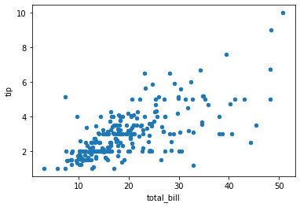

```python
tips.plot.scatter("total_bill", "tip")
```

```
array([[<AxesSubplot:xlabel='total_bill', ylabel='total_bill'>,
        <AxesSubplot:xlabel='tip', ylabel='total_bill'>,
        <AxesSubplot:xlabel='size', ylabel='total_bill'>,
        <AxesSubplot:xlabel='n_row', ylabel='total_bill'>],
       [<AxesSubplot:xlabel='total_bill', ylabel='tip'>,
        <AxesSubplot:xlabel='tip', ylabel='tip'>,
        <AxesSubplot:xlabel='size', ylabel='tip'>,
        <AxesSubplot:xlabel='n_row', ylabel='tip'>],
       [<AxesSubplot:xlabel='total_bill', ylabel='size'>,
        <AxesSubplot:xlabel='tip', ylabel='size'>,
        <AxesSubplot:xlabel='size', ylabel='size'>,
        <AxesSubplot:xlabel='n_row', ylabel='size'>],
       [<AxesSubplot:xlabel='total_bill', ylabel='n_row'>,
        <AxesSubplot:xlabel='tip', ylabel='n_row'>,
        <AxesSubplot:xlabel='size', ylabel='n_row'>,
        <AxesSubplot:xlabel='n_row', ylabel='n_row'>]], dtype=object)
```

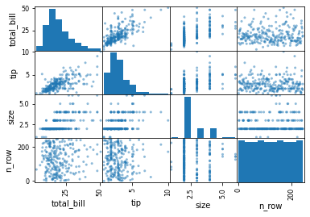

```python
pandas.plotting.scatter_matrix(tips)
```

- `seaborn` : Fonctions `jointplot()`, `regplot()` (ou `lmplot()`) et `pairplot()`

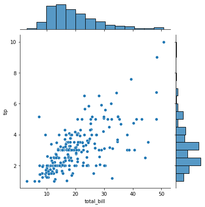

```python
seaborn.jointplot(x = "total_bill", y = "tip", data = tips)
```

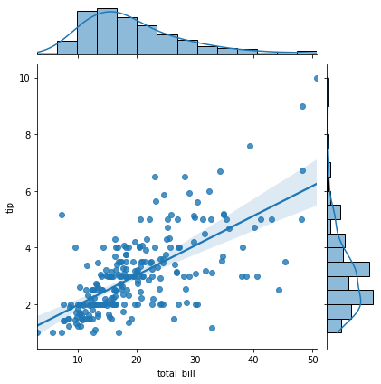

```python
seaborn.jointplot(x = "total_bill", y = "tip", data = tips, kind = "reg")
```

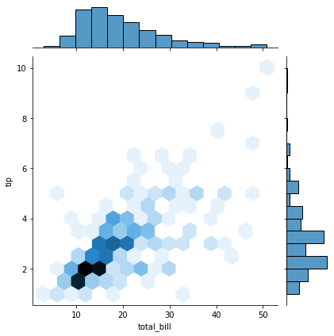

```python
seaborn.jointplot(x = "total_bill", y = "tip", data = tips, kind = "hex")
```

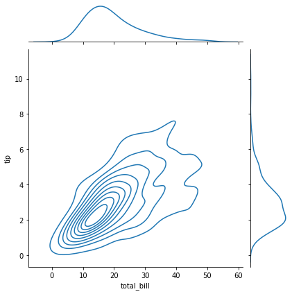

```python
seaborn.jointplot(x = "total_bill", y = "tip", data = tips, kind = "kde")
```

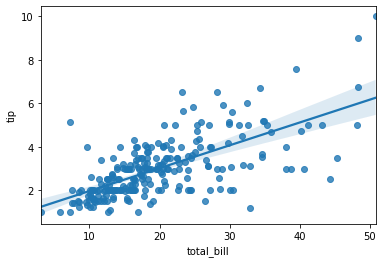

```python
seaborn.regplot(x = "total_bill", y = "tip", data = tips)
```

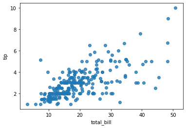

```python
seaborn.regplot(x = "total_bill", y = "tip", data = tips, fit_reg = False)
```

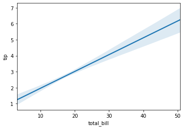

```python
seaborn.regplot(x = "total_bill", y = "tip", data = tips, scatter = False)
```

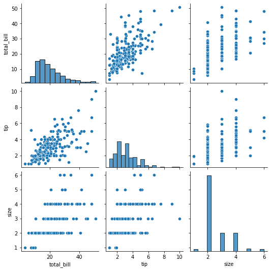

```python
seaborn.pairplot(data = tips, vars = ["total_bill", "tip", "size"])
```

### Qualitative - qualitative

- Table de contingence

```python
pandas.crosstab(tips.sex, tips.smoker)
```

| smoker sex | No | Yes |
| --- | --- | --- |
| Female | 54 | 33 |
| Male | 97 | 60 |

```python
pandas.crosstab(tips.sex, tips.smoker, margins = True)
```

| smoker sex | No | Yes | All |
| --- | --- | --- | --- |
| Female | 54 | 33 | 87 |
| Male | 97 | 60 | 157 |
| All | 151 | 93 | 244 |

```python
pandas.crosstab(tips.sex, tips.smoker, normalize = True)
```

| smoker sex | No | Yes |
| --- | --- | --- |
| Female | 0.221311 | 0.135246 |
| Male | 0.397541 | 0.245902 |

- Profils lignes et profils colonnes

```python
pandas.crosstab(tips.sex, tips.smoker, normalize = "index")
```

| smoker sex | No | Yes |
| --- | --- | --- |
| Female | 0.620690 | 0.379310 |
| Male | 0.617834 | 0.382166 |

```python
pandas.crosstab(tips.sex, tips.smoker, normalize = "index", margins = True)
```

| smoker sex | No | Yes |
| --- | --- | --- |
| Female | 0.620690 | 0.379310 |
| Male | 0.617834 | 0.382166 |
| All | 0.618852 | 0.381148 |

```python
pandas.crosstab(tips.sex, tips.smoker, normalize = "columns")
```

| smoker sex | No | Yes |
| --- | --- | --- |
| Female | 0.357616 | 0.354839 |
| Male | 0.642384 | 0.645161 |

```python
pandas.crosstab(tips.sex, tips.smoker, normalize = "columns", margins = True)
```

| smoker sex | No | Yes | All |
| --- | --- | --- | --- |
| Female | 0.357616 | 0.354839 | 0.356557 |
| Male | 0.642384 | 0.645161 | 0.643443 |

- Test du chi2

```python
t = pandas.crosstab(tips.sex, tips.smoker)
scipy.stats.chi2_contingency(t)
```

```
(0.008763290531773594,
 0.925417020494423,
 1,
 array([[53.84016393, 33.15983607],
        [97.15983607, 59.84016393]]))
```

#### Diagramme en barres

- `pandas`

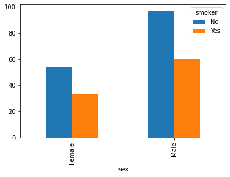

```python
t = pandas.crosstab(tips.sex, tips.smoker)
t.plot.bar()
```

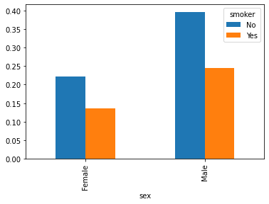

```python
t = pandas.crosstab(tips.sex, tips.smoker, normalize=True)
t.plot.bar()
```

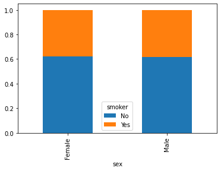

```python
t = pandas.crosstab(tips.sex, tips.smoker, normalize="index")
t.plot.bar(stacked=True)
```

```
array([<AxesSubplot:ylabel='No'>, <AxesSubplot:ylabel='Yes'>],
      dtype=object)
```

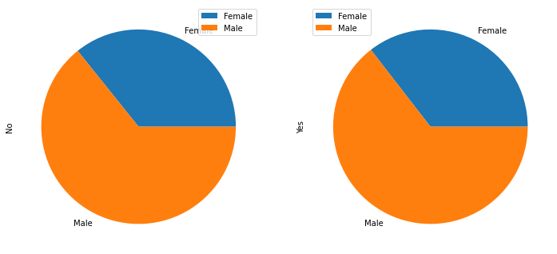

```python
t = pandas.crosstab(tips.sex, tips.smoker)
t.plot.pie(subplots=True, figsize = (12, 6))
```

- `seaborn`

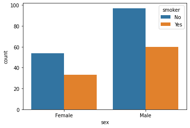

```python
seaborn.countplot(x = "sex", hue = "smoker", data = tips)
```

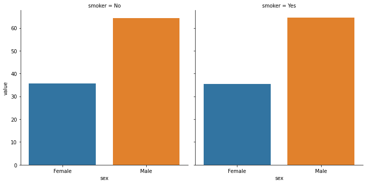

```python
t = pandas.crosstab(tips.sex, tips.smoker, normalize = "columns")
t = t.assign(sex = t.index)
tm = pandas.melt(t, id_vars = "sex")
tm = tm.assign(value = 100 * tm.value)
seaborn.catplot(x = "sex", y = "value", col = "smoker", data = tm, kind = "bar")
```

### Qualitative - quantitative

- Calcul des moyennes par modalités

```python
tips.groupby("sex").mean()
```

| sex | total_bill | tip | size | n_row |
| --- | --- | --- | --- | --- |
| Female | 18.056897 | 2.833448 | 2.459770 | 128.080460 |
| Male | 20.744076 | 3.089618 | 2.630573 | 117.853503 |

```python
tips.groupby("sex")["total_bill"].agg([numpy.mean, numpy.std, numpy.median, numpy.min, numpy.max])
```

| sex | mean | std | median | amin | amax |
| --- | --- | --- | --- | --- | --- |
| Female | 18.056897 | 8.009209 | 16.40 | 3.07 | 44.30 |
| Male | 20.744076 | 9.246469 | 18.35 | 7.25 | 50.81 |

- Test de Student (ou ANOVA)

```python
billFemale = tips.total_bill[tips.sex == "Female"]

billMale = tips.total_bill[tips.sex == "Male"]

scipy.stats.ttest_ind(billFemale, billMale)
```

```
Ttest_indResult(statistic=-2.2777940289803134, pvalue=0.0236116668468594)
```

```python
billGrouped = [tips.total_bill[tips.sex == s] for s in list(tips.sex.unique())]

scipy.stats.f_oneway(*billGrouped)
```

```
F_onewayResult(statistic=5.188345638458361, pvalue=0.023611666846859697)
```

#### Représentations graphiques

- `pandas` :

```
array([<AxesSubplot:title={'center':'Female'}>,
       <AxesSubplot:title={'center':'Male'}>], dtype=object)
```

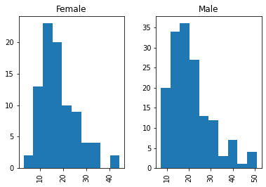

```python
tips.hist(column = "total_bill", by = "sex")
```

```
array([[<AxesSubplot:title={'center':'n_row'}, xlabel='[sex]'>,
        <AxesSubplot:title={'center':'size'}, xlabel='[sex]'>],
       [<AxesSubplot:title={'center':'tip'}, xlabel='[sex]'>,
        <AxesSubplot:title={'center':'total_bill'}, xlabel='[sex]'>]],
      dtype=object)
```

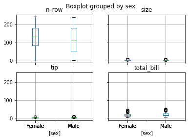

```python
tips.boxplot(by = "sex")
```

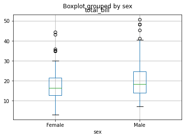

```python
tips.boxplot(column = "total_bill", by = "sex")
```

- `seaborn` :

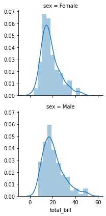

```python
p = seaborn.FacetGrid(tips, row = "sex")
p.map(seaborn.distplot, "total_bill")
```

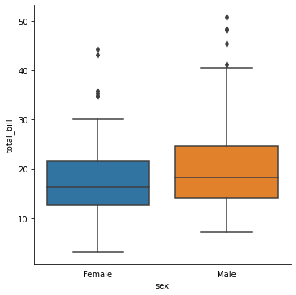

```python
seaborn.catplot(x = "sex", y = "total_bill", data = tips, kind = "box")
```

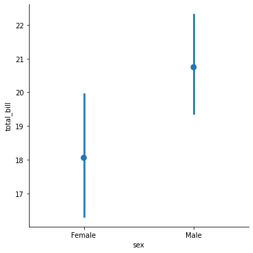

```python
seaborn.catplot(x = "sex", y = "total_bill", data = tips, kind = "point", join = False)
```

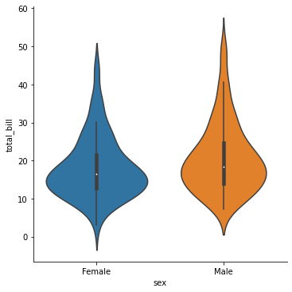

```python
seaborn.catplot(x = "sex", y = "total_bill", data = tips, kind = "violin")
```

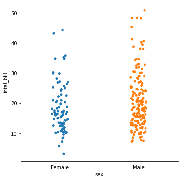

```python
seaborn.catplot(x = "sex", y = "total_bill", data = tips, kind = "strip")
```

### Compléments sur `seaborn`

- Fonction `catplot()` permettant de faire plusieurs types de graphiques

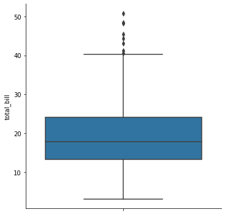

```python
seaborn.catplot(y = "total_bill", data = tips, kind = "box")
```

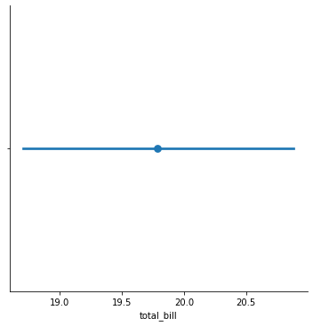

```python
seaborn.catplot(x = "total_bill", data = tips, kind = "point")
```

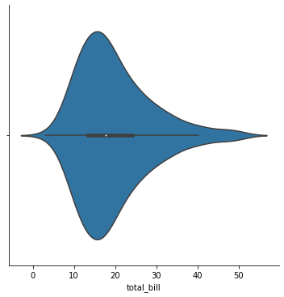

```python
seaborn.catplot(x = "total_bill", data = tips, kind = "violin")
```

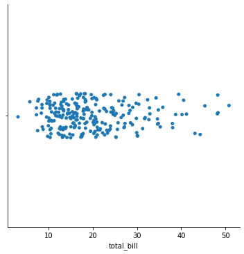

```python
seaborn.catplot(x = "total_bill", data = tips, kind = "strip", jitter = True)
```

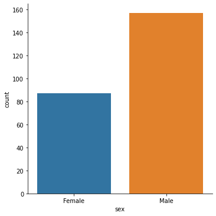

```python
seaborn.catplot(x = "sex", data = tips, kind = "count")
```

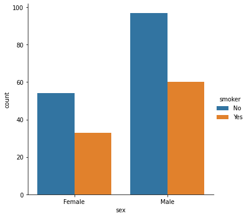

```python
seaborn.catplot(x = "sex", hue = "smoker", data = tips, kind = "count")
```

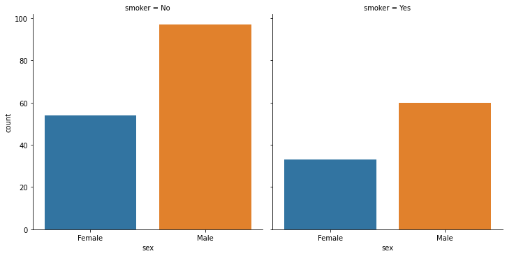

```python
seaborn.catplot(x = "sex", col = "smoker", data = tips, kind = "count")
```

#### Représentation de 3 variables quantitatives

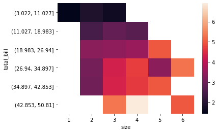

```python
t = pandas.crosstab(pandas.cut(tips.total_bill, bins = 6),
                    tips["size"],
                    values = tips.tip, aggfunc = numpy.mean)
seaborn.heatmap(t)
```

#### Représentation de 2 variables quantitatives avec 1 qualitative

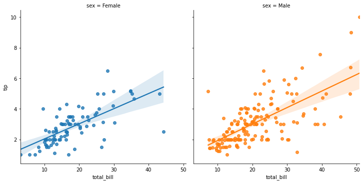

```python
seaborn.lmplot(x = "total_bill", y = "tip", hue = "sex", col = "sex", data = tips)
```

#### Représentation d' 1 variable quantitative et de 2 variables qualitatives

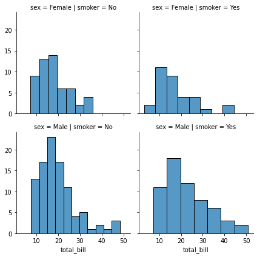

```python
p = seaborn.FacetGrid(tips, row = "sex", col = "smoker")
p.map(seaborn.histplot, "total_bill")
```

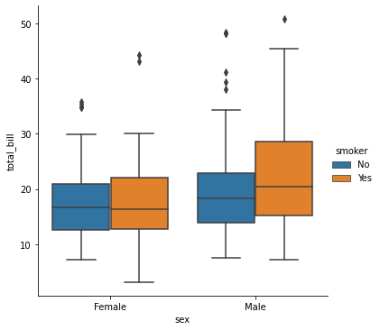

```python
seaborn.catplot(x = "sex", y = "total_bill", hue = "smoker", data = tips, kind = "box")
```

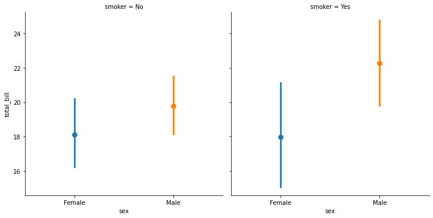

```python
seaborn.catplot(x = "sex", y = "total_bill", hue = "sex", col = "smoker", data = tips,
                   kind = "point", join = False)
```

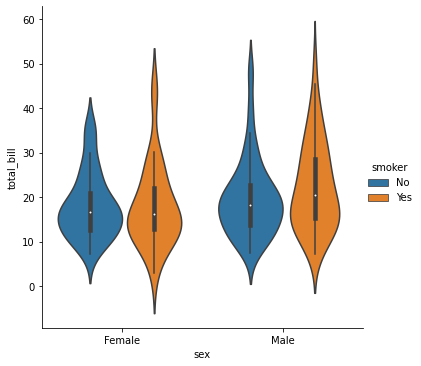

```python
seaborn.catplot(x = "sex", y = "total_bill", hue = "smoker", data = tips, kind = "violin")
```

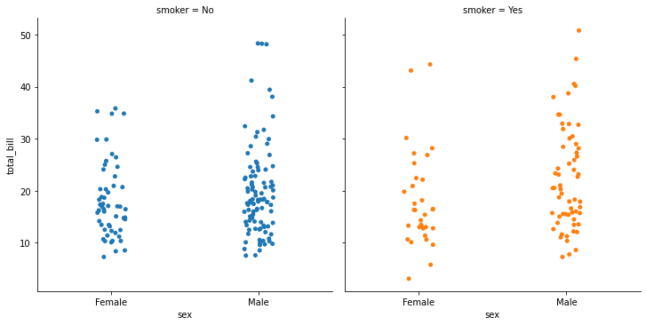

```python
seaborn.catplot(x = "sex", y = "total_bill", hue = "smoker", col = "smoker", data = tips,
                   kind = "strip", jitter = True)
```

#### Représentation de 3 variables qualitatives

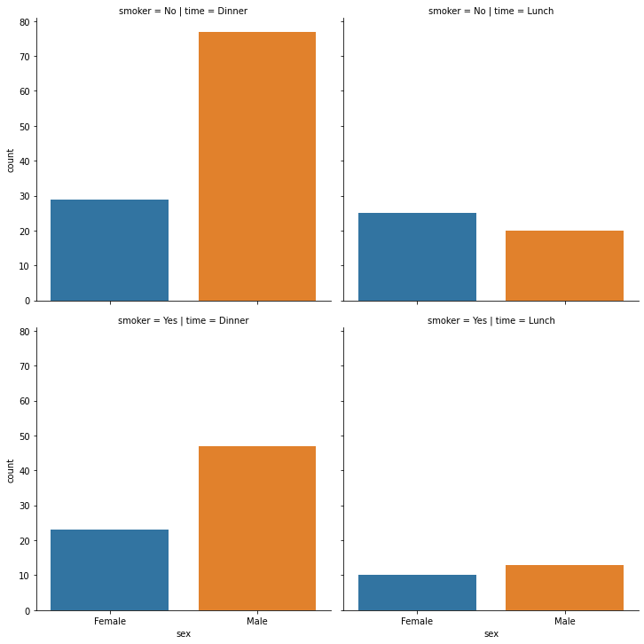

```python
seaborn.catplot(x = "sex", row = "smoker", col = "time", data = tips, kind = "count")
```

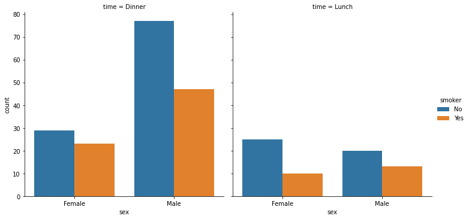

```python
seaborn.catplot(x = "sex", hue = "smoker", col = "time", data = tips, kind = "count")
```

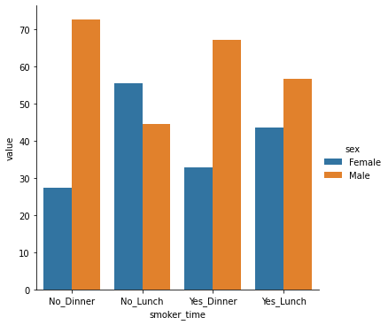

```python
t = pandas.crosstab([tips.smoker, tips.time], tips.sex, normalize = "index")
t = t.reset_index().assign(smoker_time = lambda x: x.smoker + "_" + x.time).drop(columns = ["smoker", "time"])
tm = pandas.melt(t, id_vars = "smoker_time")
tm = tm.assign(value = 100 * tm.value)
seaborn.catplot(x = "smoker_time", y = "value", hue = "sex", data = tm, kind = "bar")
```

## Compléments sur `seaborn`

- Possibilité de personnaliser le graphique de différentes façons
- Accès via
  - des paramètres de la fonction,
  - l'objet renvoyé par la fonction utilisée pour créer le graphique,
  - le module directement (changements pour les graphiques futurs aussi)
- Quelques exemples
  - `suptitle` dans `fig` : titre global
  - `set_axis_labels` : titre des axes
  - `palette` : choix d'une palette de couleurs
  - `height` et `aspect` : hauteur et ratio entre hauteur et largeur, pour chaque facette (une seule ici)
  - ...

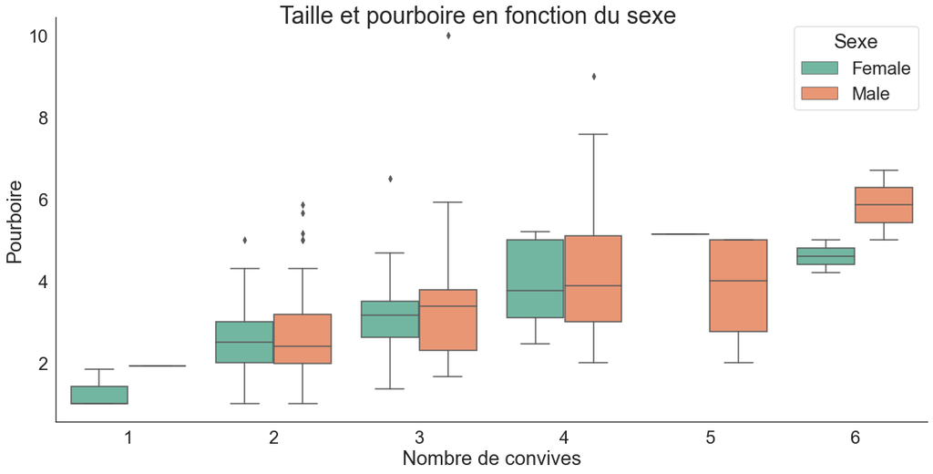

```python
seaborn.set(font_scale=2, style="white")

p = seaborn.catplot(x = "size", y = "tip", hue = "sex", data = tips, kind = "box",
                    palette = "Set2", height = 8, aspect = 2, legend = False)

p.fig.suptitle("Taille et pourboire en fonction du sexe")

p.set_axis_labels("Nombre de convives", "Pourboire")

matplotlib.pyplot.legend(title='Sexe', loc='upper right')

matplotlib.pyplot.show()
```